# R Notebook

Group 3: Komal Luthra Verma, Lucky Sikka, Olayemi Agogbua, Souvik Nnandi

install.packages(‘tinytex’) tinytex::install_tinytex()

latexmk(engine = ‘pdflatex,’ emulation = TRUE) update.packages(ask = FALSE, checkBuilt = TRUE) tinytex::tlmgr_update() options(tinytex.verbose = TRUE)

library(tinytex) install.packages(‘tinytex’) tinytex::install_tinytex() if (!require(“pacman”)) install.packages(“pacman”) pacman::p_load(knitr, captioner, bundesligR, stringr)

# Executive Summary

The objective of this project is to predict passengers for the existing and the new bus routes in the county of Surrey, England based on the features in the given database. The data was provided by the Surrey county council and consists of 37 bus operators from the period starting November 2015 to September 2018. The database BusServices was imported into R through PGadmin using SQL queries. The data analysis has been done on mainly two tables:

1. routes_daily_distinct: daily route information
2. routes_aggr_distinct: gives route information for the entire period from 2015 to 2018 aggregated by routes

# Literature Review

In view of the primary objective of the project of finding a model that predicts the number of passengers for new and existing routes for bus services in Surrey, UK, it was determined that the iterative sequence of the knowledge discovery from the database process (KDD) would be carried out to perform predictive analysis. The purpose of this literature review is to analyse the KDD process with a focus on predictive analytics data mining techniques on bus service time series data. Bus transport is one of the most comprehensive and affordable means of transport around the globe and most people rely on it in their daily work and life. From an environmental and passenger perspective, bus transport services reduce consumption of fuel, usage of private cars, and ease traffic congestion. Headway, cost, distance, and comfort are some of the factors passengers consider using bus services. Excessively overcrowded buses for example may discourage some passengers from taking buses. From a transport management perspective, it is pertinent to adequately predict passenger travel demand on various routes and within different intervals (Zhou, Dai, and Li (2013))

A review of five predictive analysis research on bus services and transport-related objectives was carried out to identify possible models that could be used to predict passengers for new and existing routes in Surrey. The results below present a range of techniques that have been used in creating models for prediction.

1. Neural Networks and Wavelet Analysis were used to improve the prediction accuracy for passenger flow forecasting in Jilin Province, China (Zhao et al., 2011). The Neural Networks had higher accuracy.
2. Auto-Regressive Moving Average (ARMA), Seasonal Autoregressive Integrated Moving Average (SARIMA), Autoregressive Integrated Moving Average (ARIMA) and Interactive Multiple Model (IMM) were used on a weekly, daily, 15 minutes and hybrid time series data respectively Shenzhen, China to set up time series models for short-term bus passenger demand based on historical data Xue, Sun, and Chen (n.d.) (Xue et al., 2015). IMM provided the best accuracy.
3. 2 Step Real-Time Prediction (2 RTP), ARIMA and Linear Regression were used to analyse and predict the passenger flow in Shenzhen, China in real-time (Zhang et al. (2017)). 2 RTP provided the best accuracy.
4. Relevance Vector Machines (RVM) and Support Vector Machines (SVM) were used to provide public transportation information services to the public, reduce passengers’ travel times, and improve operational and management levels of public transportation in Beijing, China (Ma and Chen (2019)). RVM provided the best accuracy.
5. Long Short-Term Memory (LSTM), a type of Neural Network, SVM, ARIMA, & Naive were used to develop an effective framework to model short-term bus passenger flow in Shenzhen, China and make accurate predictions (Han, Pei, and Kamber (2011)). LSTM provided the best accuracy

Of the existing traffic flow prediction methods, Neural Networks (NN) are the most widely used ones. Karlaftis and Vlahogianni (2011) believe that NN are very broad, precise and accessible mathematical models that can simulate numerical model components easily. They further go ahead to state that NN have been mainly used as data analytic methods in transport research because of their modelling flexibility, their ability to work with copious amounts of multi-dimensional data, their learning and generalization ability, their adaptability and their generally good predictive ability. There are however several other researchers who posit the use of SVM to address the limitations of NN. It is however worthy to note that despite the above-listed research being of similar transportation-related nature, differences exist in their core objectives and types of data. In addition, Despite the progress in various aspects of intelligent transportation and traffic management areas, only a limited number of surveys can be found that review the growing body of literature focusing on data mining, artificial intelligent algorithms and techniques adopted in these areas (Alsrehin, Klaib, and Magableh (2019)). In view of the above findings, the following methods were used to train and test models to predict the passengers for new and existing routes: Regression, Decision Trees, Neural Networks, SVM and ARIMA.

# Data Explanation and Preparation

The data for the Bus Services project is obtained from the Surrey county council from November 2015 to September 2018. There are a total of 37 bus operators and a total of 270 routes with distinct bus service numbers operating in Surrey. Out of these, 87 routes with different service numbers are analysed. The passenger numbers in the data set are the aggregated values & individual ticket data was used to calculate the aggregated values. Surrey’s Bus Services map is created using 10 different tables:

- bus_route (bus routes)
- bus_stop (bus stops)
- train_stations (train stations)
- hospital (hospitals)
- households (delivery points)
- household_domestic_surrey (households)
- town - (town & village names)
- surrey_boundary (border of Surrey)
- routes_daily_distinct (daily bus route information)
- routes_aggr_distinct (bus route information over the entire time period)

The ‘routes_daily_distinct’ and ‘routes_aggr_distinct’ were the main tables used for data analysis and the creation & selection of model with the least error to predict passengers for new and existing routes. The BusServices database was imported into R through PGadmin using SQL queries. Analysis was done using ‘passenger_avg’ as the target variable and ‘bus operator,’ ‘route,’ ‘weekday,’ ‘peak,’ ‘sdate,’ ‘deviation,’ ‘headway,’ ‘households,’ ‘hospitals’ and ‘train stations’ as the predictor or independent variables.

### Data Preparation and Cleaning

When the data was summarised in SQL & R, some missing values were discovered in tables for the headway and deviation variables. Due to their limited number, the missing values were removed to avoid errors. After data cleansing, the routes_aggr_distinct and routes_daily_distinct tables were observed to have 244 distinct rows and 57,834 rows respectively. There are a total of 12 modelling variables, including passengers, weekday, peak, deviation, household, train station, headway etc. To establish and identify the relationship between the variables, correlation is carried out. The results of the correlation matrix are elucidated in the data visualisation section. Passenger is the response variable in the analysis basis which all models are created. Therefore, for predicting the passengers on the existing route, Power BI is used on routes_daily_distinct table using the time series forecasting model Autoregressive Integrated Moving Average (ARIMA), in R. Machine learning models like Linear model, Linear Regression, Decision tree, Random Tree, Neural Networks, Linear Support Vector Machine and Random forests are used for prediction for new routes in R.

# Data Visualisation

Data visualisation is the process of translating data into a visual representation, in the form of a figure, map or a graph, to comprehend and extract insights from the data. The purpose is to make it easier to spot any patterns, trends, and outliers in the data set. We have used routes_daily_distinct tables to understand any trends or patterns in the data.

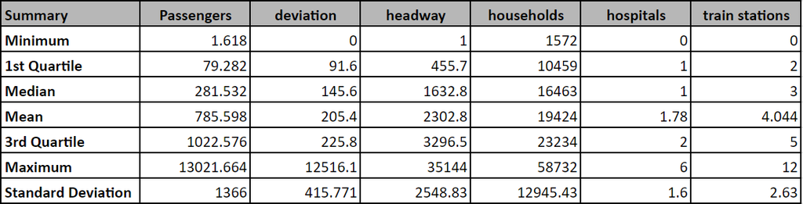

Summary Statistics

Table 1: Summary statistics of data features

The range of the features can be seen in table 1. Certain variables like passengers, deviation, headway and households have higher ranges than the other two variables hospitals and train stations.

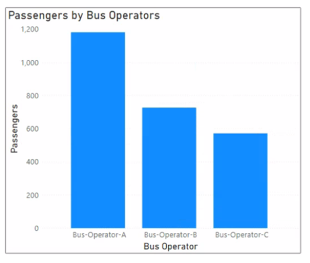

*Figure 1*

Figure 1 indicates the average Passengers for the 3 bus operators A, B & C. It is evident that the bus routes operated by operator A have more passenger footfall than bus operators B & C.

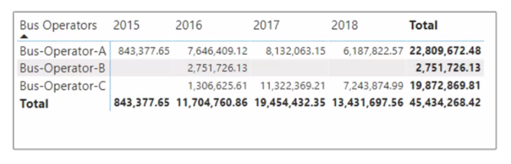

*Table2*

Table 2 shows the yearly total footfall of passengers for each of the bus operators. The data indicates that the routes operated by operators A and C were used by the majority of passengers, however, not many passengers have traveled on the routes operated by operator B. This is because operator B operated only during the year 2016.

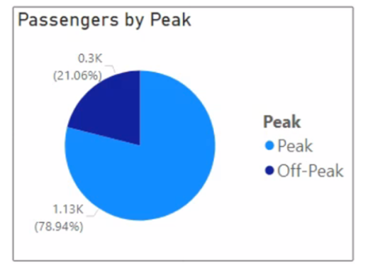

*Figure 2*

Figure 2 demonstrates the average passengers during peak and off-peak hours. The footfall of passengers during peak hours is 3 times more than that of off-peak hours.

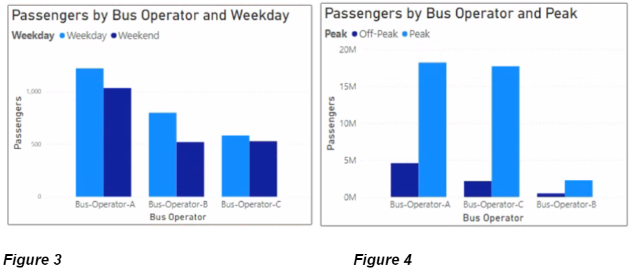

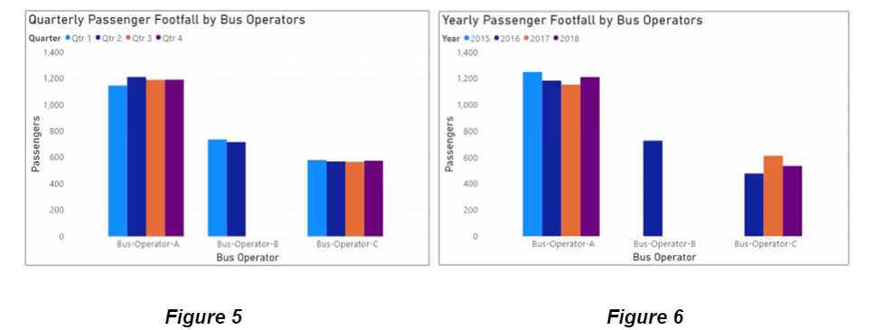

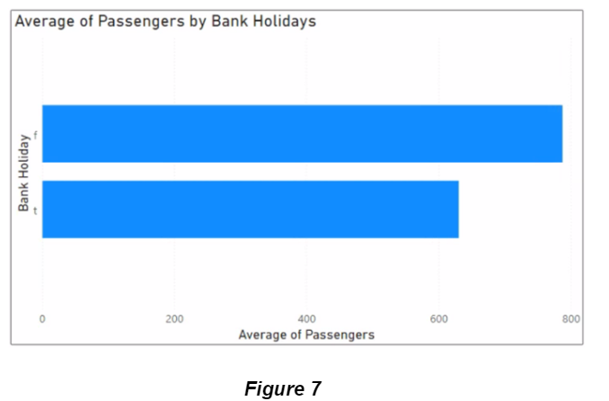

Figure 7 illustrates the average passenger footfall on the bank holidays and non-holidays. Although there is not much difference, the footfall is higher on non-holidays than the bank holidays. So, to predict the passengers, a filter of bank holiday and non-holiday can be used as a predictor.

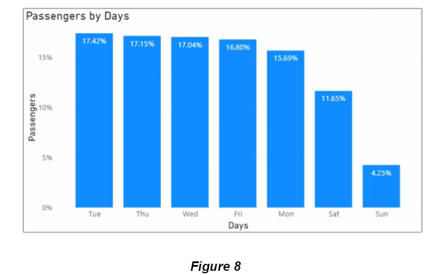

Figure 8 shows the average percentage of passenger footfall for each day in a week across all routes. It is evident from the graph that the weekdays have a considerably high percentage of passengers traveling by bus as compared to weekends. Also, the number of passengers traveling on Sunday is much less than Saturdays. During weekdays, footfall is less on Mondays among the other weekdays in a week.

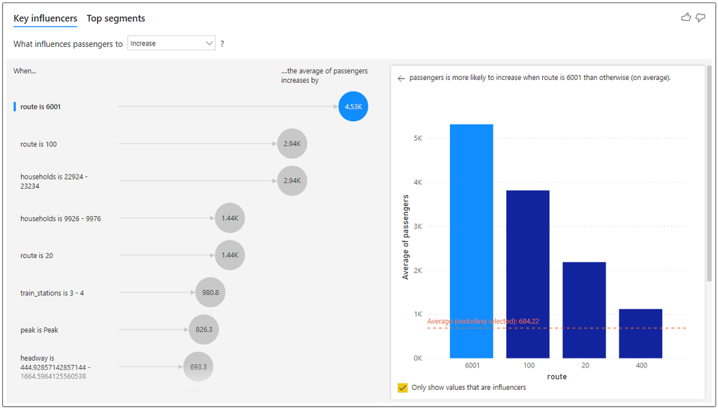

*Figure 9*

### Correlation Matrix

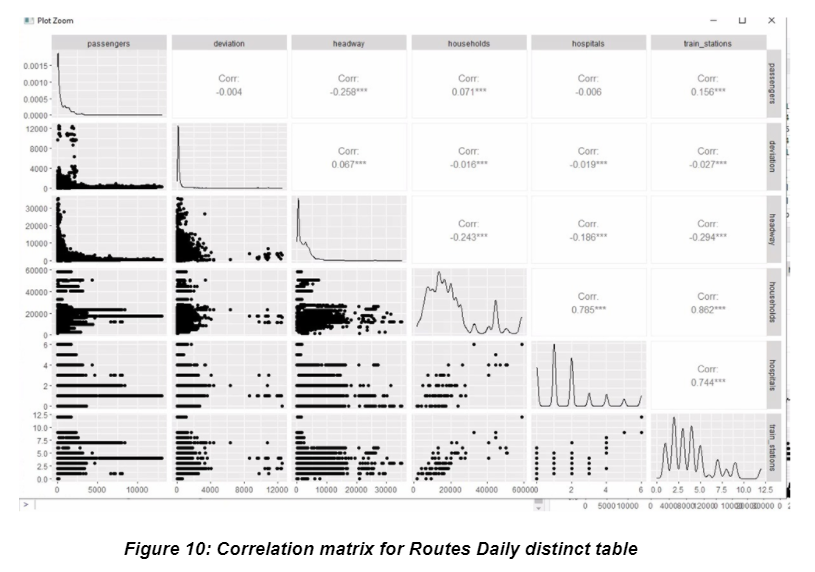

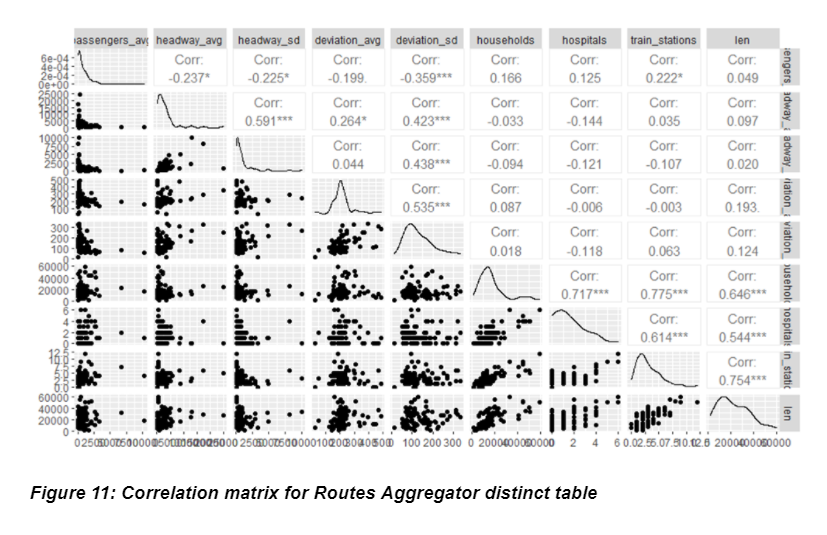

### Forecasting

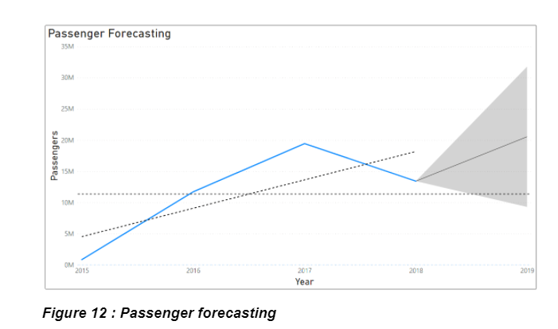

Figure 12 demonstrates the forecasting of passengers for next 1 year based on the dataset provided from 2015 to 2018. The passenger forecasting has been made at 95% confidence interval and has been used to predict the passengers on existing bus routes.

# Prediction and Classification Methods

Feature Selection: The most crucial step before deciding on the prediction or classification methods is the feature selection. It is one of the primary components and techniques of determining the most significant features to use as predictors in machine learning algorithms. Feature selection aims to identify a small subset of the significant features from the original set of features by removing unnecessary, redundant, or noisy variables as a dimensionality reduction technique. It generally leads to improved learning accuracy, improved learning performance, reduced cost of computation, and accurate model interpretability.

The feature selection for this project was done based on the relationship derived from correlation matrix of the variables and the objective of this project. The Surrey county council needs an idea of possible passenger footfall on each route at specific times of the day, to plan the buses in each route to avoid overcrowding. It is evident from the data visualization that more passengers travel on weekdays during peak hours. Therefore, the dataset was filtered for these two factors.

It is observed that certain variables have high range (difference between the minimum & maximum value of the variable), as inferred from Table 1, may make the models biased towards the features having a high range. Therefore, log versions of passengers_avg, deviation_avg, households, headway_avg have been created to reduce the skewness of the variables and to normalize the range, so that the models can be free of any biases.

The models were run on the log versions of the variables created. However, when the RMSE & MAPE values came too low, it indicated evidence of overfitting of the model. Therefore, log_passenger_avg was dropped. After the features were selected and data filtered, the final models were run on the variables ‘passengers_avg,’ ‘log of headway_avg,’ ‘log of deviation_avg,’ ‘log of households,’ ‘log of len,’ ‘hospitals,’ train_stations for weekdays and peak hours routes.

## Prediction Models - New bus routes

In this project, there are two objectives, one is to predict the passengers for the new bus routes, and the other to forecast passengers on the existing routes.

Based on the findings of the literature review, we have used six prediction models for predicting the passengers for the new bus routes. The dataset used for this is the ‘route_aggr_distinct’ table. The first step towards running a model is to divide the dataset into training and test data, so that the algorithm created on the training data can be tested on the test data. For this we have used two combinations, keeping the ratio of training to test data as 70:30 and 80:20. We have then run the six models on both combinations and the measured the accuracy of the models by two error metrics: 1. Mean Absolute Percentage Error (MAPE) - most widely used measure for checking forecast accuracy. 2. Root Mean Square Error (RMSE) - standard way to measure the error of a model in predicting quantitative data. The lower values of RMSE & MAPE indicate better accuracy of the model and better predictions. The table below lists all the six models and their accuracy with both the combinations of training to test data.

$$\mathrm{MSE}=\frac{1}{n} \sum_{k=1}^{n}\left(y_{k}-\hat{y_{k}}\right)^{2}$$

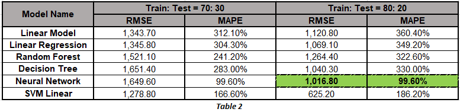

### Models: Train to Test ratio - 70:30

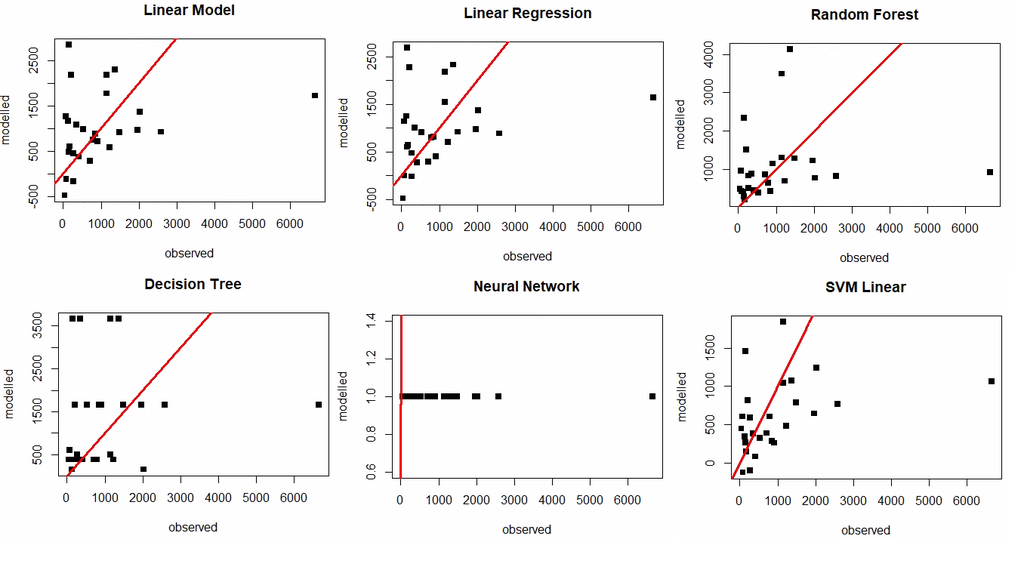

### Models: Train to Test ratio - 80:20

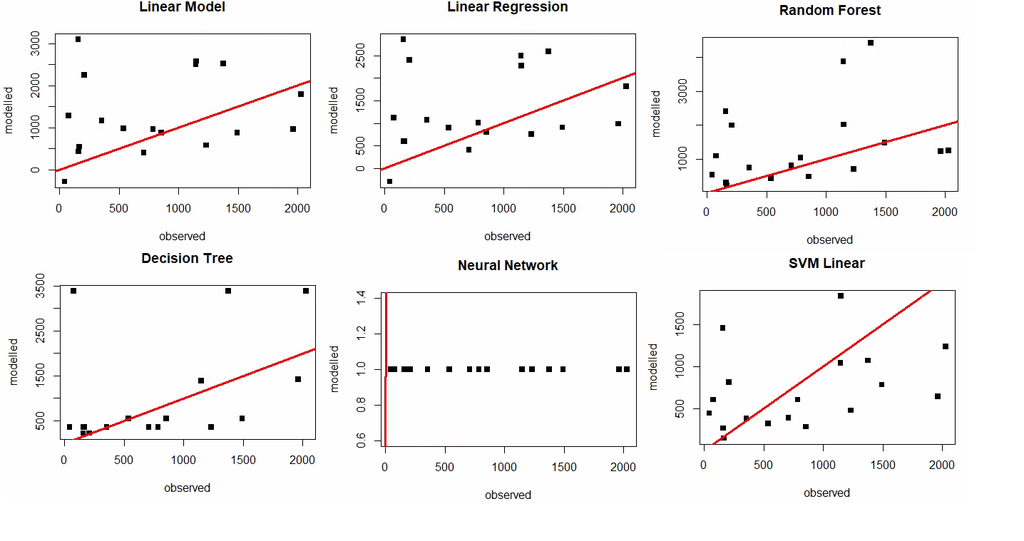

## Prediction Model - Existing bus routes

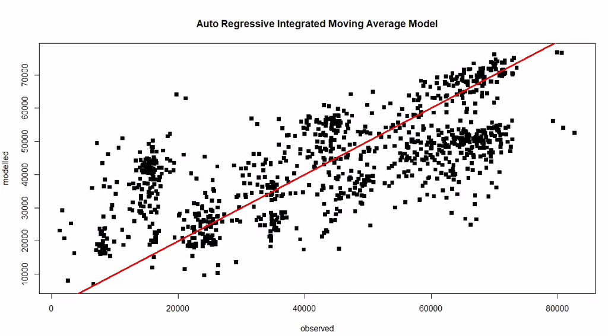

# SQL Queries:

select count(*) from routes_aggr;

select count(*) from(select distinct* from routes_aggr) a;

create table routes_aggr_distinct as select distinct * from routes_aggr;

select count(*) from routes_aggr_distinct;

select count(*) from routes_daily;

select count(*) from(select distinct* from routes_daily) a;

create table routes_daily_distinct as select distinct * from routes_daily; select count(*) from routes_daily_distinct;

select min(passengers),max(passengers),avg(passengers),stddev(passengers) from routes_daily_distinct;

select min(deviation),max(deviation),avg(deviation),stddev(deviation) from routes_daily_distinct;

select min(headway),max(headway),avg(headway),stddev(headway) from routes_daily_distinct;

select min(households),max(households),avg(households),stddev(households) from routes_daily_distinct;

select min(hospitals),max(hospitals),avg(hospitals),stddev(hospitals) from routes_daily_distinct;

select min(train_stations),max(train_stations),avg(train_stations),stddev(train_stations) from routes_daily_distinct;

Codes chunks:

```r
#### Defining Function
library(pacman); p_load(tidyverse)
```

```r
source("C:/Users/oa01018/OneDrive - University of Surrey/Desktop/BusService/da_busservice/HumanNumbers.R")
rmse  <- function(y,yh) {sqrt(mean((y-yh)^2))}
mape  <- function(y,yh) {mean(abs((y-yh)/y))} # y=actual value, yh=modelled value (note issue when y is zero!)
frmse <- function(y,yh) {fmt(rmse(y,yh))}
fmape <- function(y,yh) {fmt(mape(y,yh)*100,'%')}
derr  <- function(y,yh,model="") {disp(model,'rmse=',frmse(y,yh),', mape=',fmape(y,yh))}
aplot <- function(y,yh, main="") {
  plot(y, yh, pch='.', cex=8, col = 'black',
       ylab = "modelled", xlab = "observed",main=main);
  abline(0,1, lwd=3, col='red');
}

####  Connecting Group03 database from SQL

library(DBI)
con <- DBI::dbConnect(odbc::odbc(),
driver = "PostgreSQL ANSI(x64)",
database = "group03", Uid = "group03", Pwd = "group03.",
server = "cp-vms-ts1-01.surrey.ac.uk", port = 5432)

####  Fetching Table from SQL : ROUTES DAILY

sql = "select distinct * from routes_daily"
File12 = dbGetQuery(con, sql);
View(File12)
saveRDS(File12, 'routes_daily.rds')

####  Fetching Table from SQL : ROUTES AGGR

sql = "select distinct * from routes_aggr"
File2 = dbGetQuery(con, sql);
View(File2)
saveRDS(File2, 'routes_aggr.rds')

####  Library & Packages

library(pacman); p_load(RPostgreSQL, DBI)
#install.packages("GGally")
library(GGally)
####  Checking of Missing Values

length(which(is.na(File12))==TRUE)
```

```
## [1] 14
```

```r
length(which(is.na(File2))==TRUE)
```

```
## [1] 3
```

```r
####  Fixing Mising Values

File2=na.omit(File2)

# Checking of Missing Values after fixation
length(which(is.na(File2))==TRUE)
```

```
## [1] 0
```

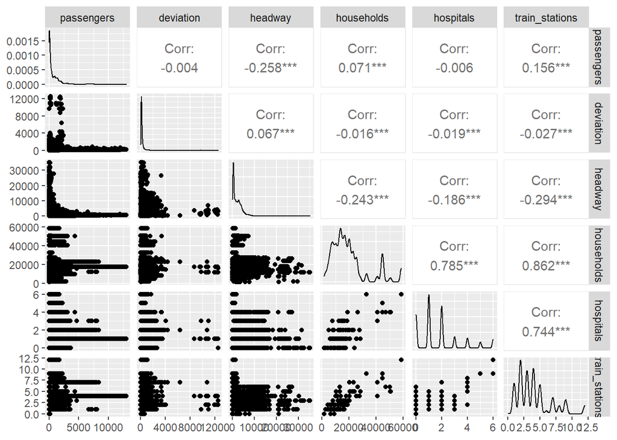

```r
####  checking correlation after removing the Geom & routes

File3 = File2 %>% dplyr::select(-c(geom,route))

Filecor = File12 %>% dplyr::select(-c(route,bus_operator,peak,weekday,sdate,bankholiday))
ggpairs(Filecor)
```

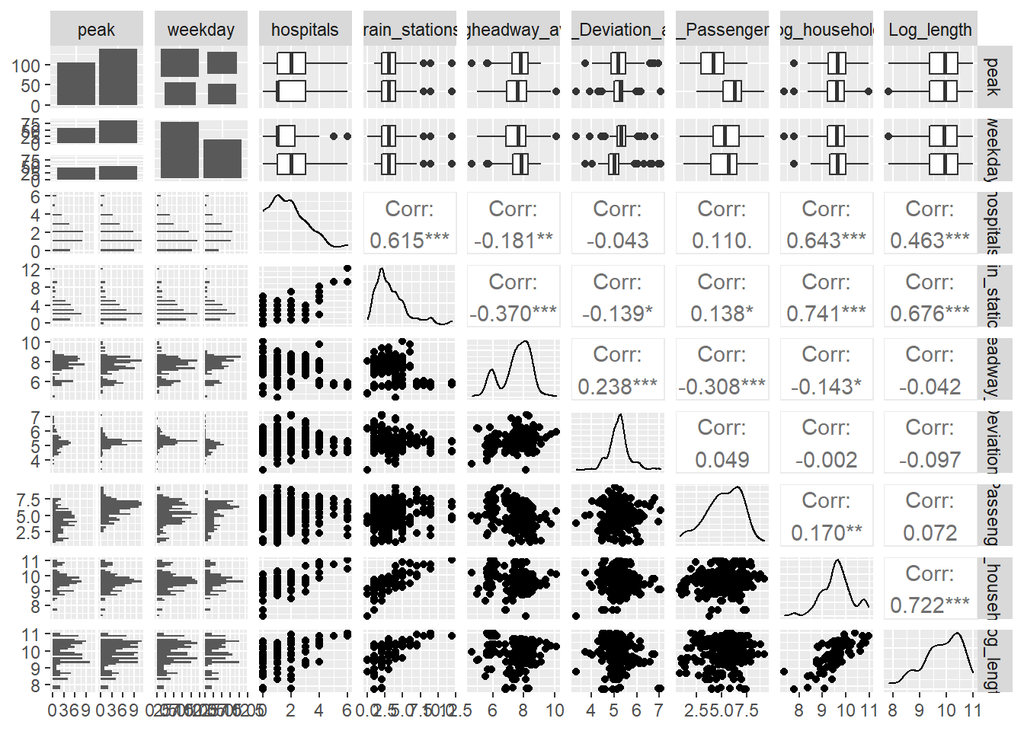

```r
####  Make Log Version of Headway Average

File3$logheadway_avg=log(File3$headway_avg)


####  Make Log Version of Deviation Average

File3$log_Deviation_avg=log(File3$deviation_avg)


####  Make Log Version of Passenger Average

File3$Log_Passengeravg=log(File3$passengers_avg)

library(pacman); p_load(tidyverse)

####  Feature selection A

File3A = subset(File3, select = -c(bus_operator,deviation_avg,headway_avg,passengers_avg,headway_sd,deviation_sd,passengers_sd) )

File3$log_household=log(File3$households)
File3$Log_length=log(File3$len)

####  Feature selection B

File3B = subset(File3, select = -c(bus_operator,deviation_avg,headway_avg,passengers_avg,headway_sd,deviation_sd,passengers_sd,households,len) )

ggpairs(File3B)
```

```
## Linear Model: rmse=1,343.7, mape=312.1%
```

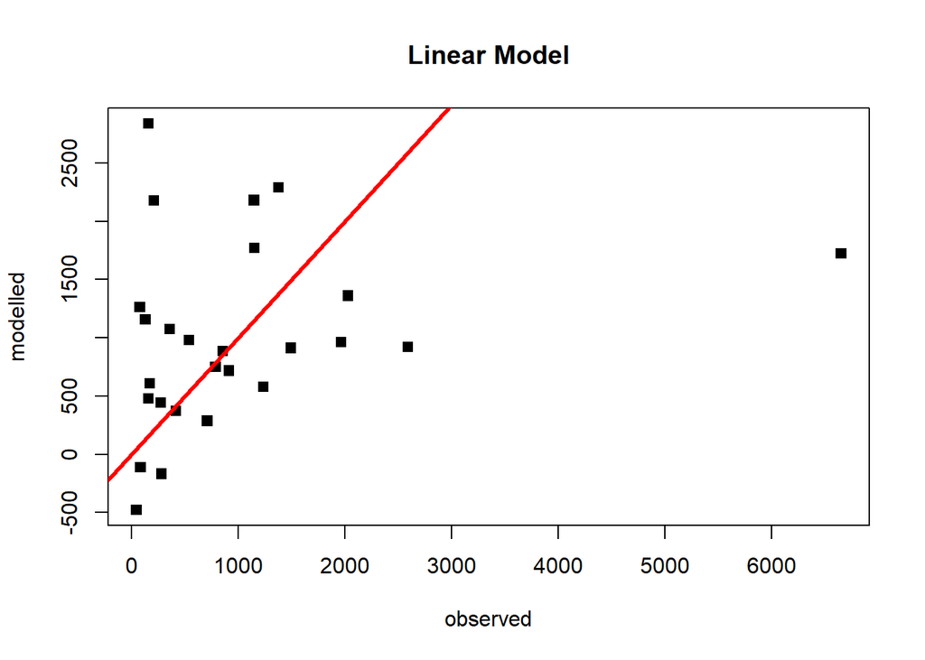

```r
####  Feature selection & Filter of Peak & weekday

File3C = File3 %>% filter(peak == "Peak", weekday == "Weekday")
FILE3D = File3C %>% dplyr::select(-c(bus_operator,weekday, peak,deviation_avg,headway_avg,Log_Passengeravg,headway_sd,deviation_sd,passengers_sd,households,len) )

####  Dividing the data in to Test (nr) and Train (nt)

nr = length(FILE3D$passengers_avg); nt=floor(.7*nr);
set.seed(123); train = sample(1:nr, nt);


#### Model 1 : Linear Model

m1<- lm ( passengers_avg~., data = FILE3D[train,])
yh  = predict(m1, newdata=FILE3D[-train,])
y   = FILE3D$passengers_avg[-train]
derr(y,yh,"Linear Model: "); aplot(y,yh,"Linear Model")
```

```r
summary(m1)
```

```
##
## Call:
## lm(formula = passengers_avg ~ ., data = FILE3D[train, ])
##
## Residuals:
##     Min      1Q  Median      3Q     Max
## -1511.9  -787.7  -128.6   377.7  8439.4
##
## Coefficients:
##                   Estimate Std. Error t value Pr(>|t|)
## (Intercept)        2841.45    4021.01   0.707   0.4829
## hospitals          -180.28     170.99  -1.054   0.2965
## train_stations      -11.16     150.17  -0.074   0.9411
## logheadway_avg     -429.29     201.43  -2.131   0.0377 *
## log_Deviation_avg  -992.30     533.30  -1.861   0.0683 .
## log_household       839.88     475.87   1.765   0.0833 .
## Log_length         -121.30     410.10  -0.296   0.7685
## ---
## Signif. codes:  0 '***' 0.001 '**' 0.01 '*' 0.05 '.' 0.1 ' ' 1
##
## Residual standard error: 1418 on 53 degrees of freedom
## Multiple R-squared:  0.1698, Adjusted R-squared:  0.07579
## F-statistic: 1.806 on 6 and 53 DF,  p-value: 0.1156
```

```
## Linear Regression: rmse=1,345.8, mape=304.3%
```

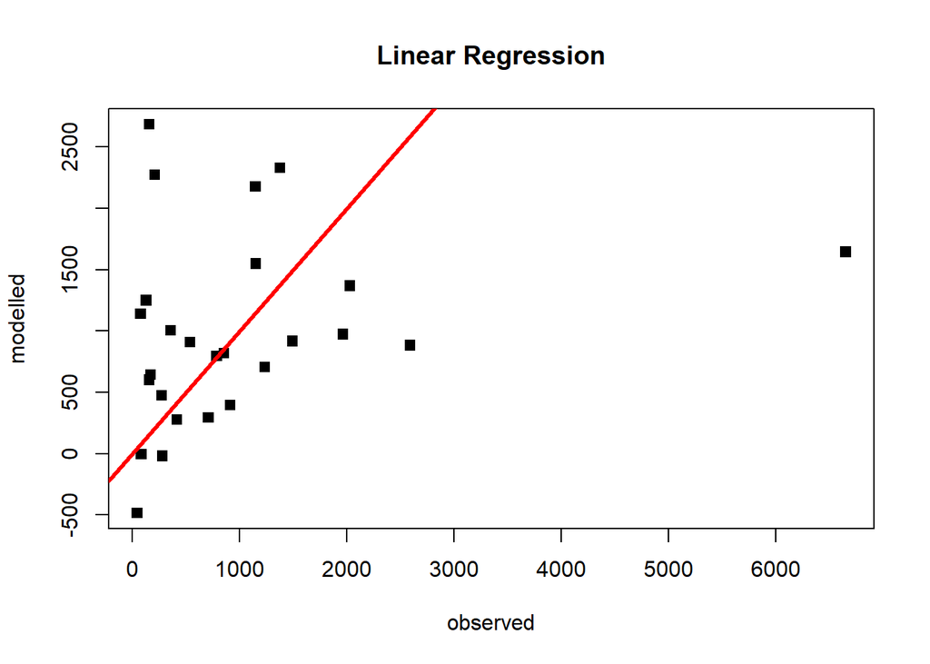

```r
#### Model 2 : Linear Regression


p_load(MASS)
ya = FILE3D$passengers_avg[train]
pX = FILE3D %>% dplyr::select(-c(passengers_avg))
X = as.matrix( pX[train,])
b = ginv(t(X) %*% X) %*% t(X) %*% ya

y = FILE3D$passengers_avg[-train]
Xt = as.matrix( pX[-train,])
yh = Xt %*% b
derr(y,yh,"Linear Regression: "); aplot(y,yh,"Linear Regression")
```

```
## Random Forest : rmse=1,521.1, mape=241.2%
```

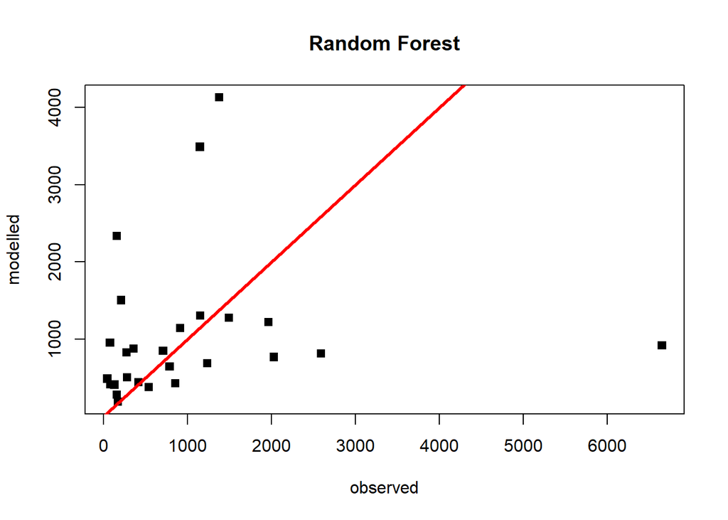

```r
#### Model 3 : Random Forest Model

p_load(randomForest)
set.seed(123);
rf = randomForest(formula = passengers_avg~., data = FILE3D, subset=train, importance = TRUE)
yh2  = predict(rf, newdata=FILE3D[-train,])
y2   = FILE3D$passengers_avg[-train]
derr(y2,yh2,"Random Forest : "); aplot(y2,yh2,"Random Forest")
```

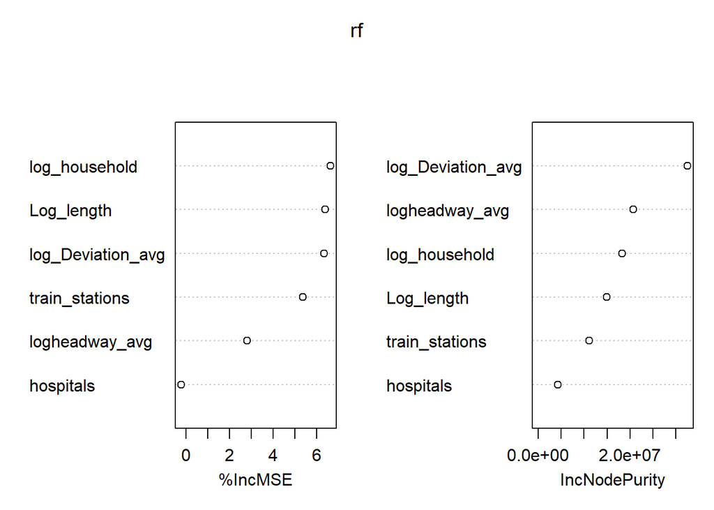

```r
I = importance(rf);I = I[order(-I[,1]),]
varImpPlot(rf)
```

```
## Decision Tree : rmse=1,651.4, mape=283.0%
```

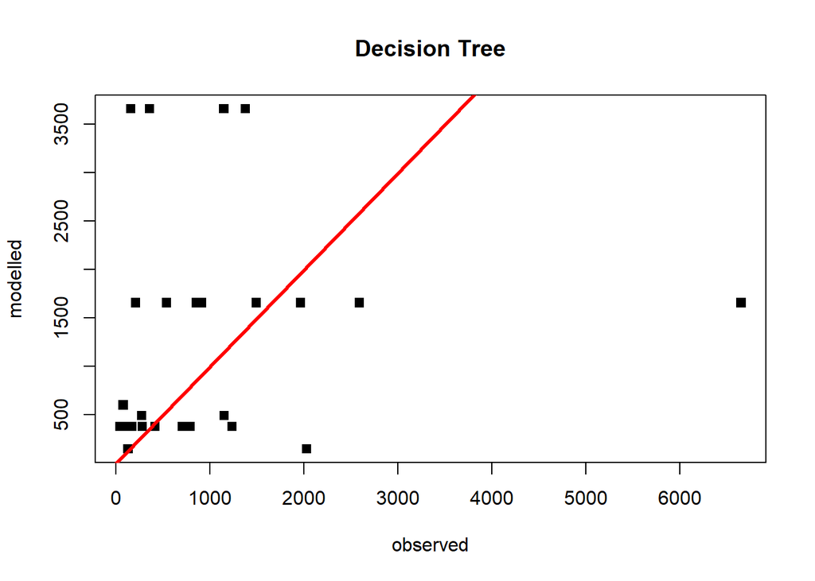

```r
#### Model 4 : Decision Tree
p_load(tree)
dt = tree(passengers_avg~., data = FILE3D, subset=train)
yh  = predict(dt, newdata=FILE3D[-train,])
y   = FILE3D$passengers_avg[-train]
derr(y,yh,"Decision Tree : "); aplot(y,yh,"Decision Tree")
```

```
## Neural Network: rmse=1,649.6, mape=99.6%
```

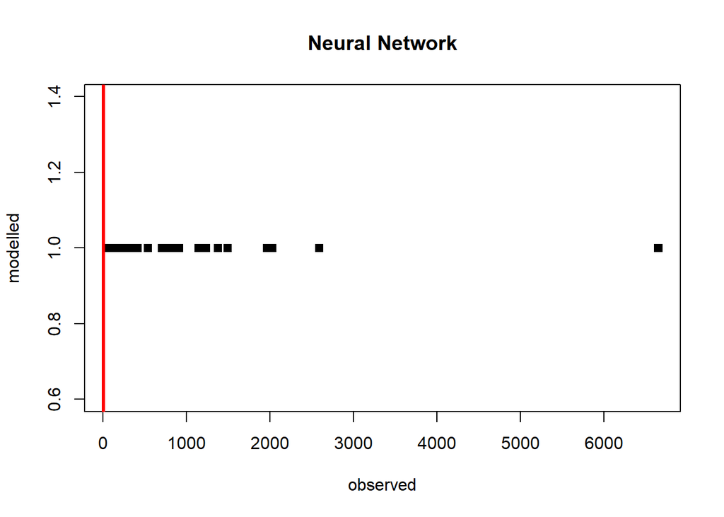

```r
#### Model 5 : Neural Network

p_load(neuralnet)
require(neuralnet)
nn=neuralnet(passengers_avg~.,data=FILE3D,hidden=1,act.fct="logistic",linear.output=FALSE)
yh  = predict(nn, newdata=FILE3D[-train,])
y   = FILE3D$passengers_avg[-train]
derr(y,yh,"Neural Network: "); aplot(y,yh,"Neural Network")
```

```
## SVM Linear: rmse=1,278.8, mape=166.6%
```

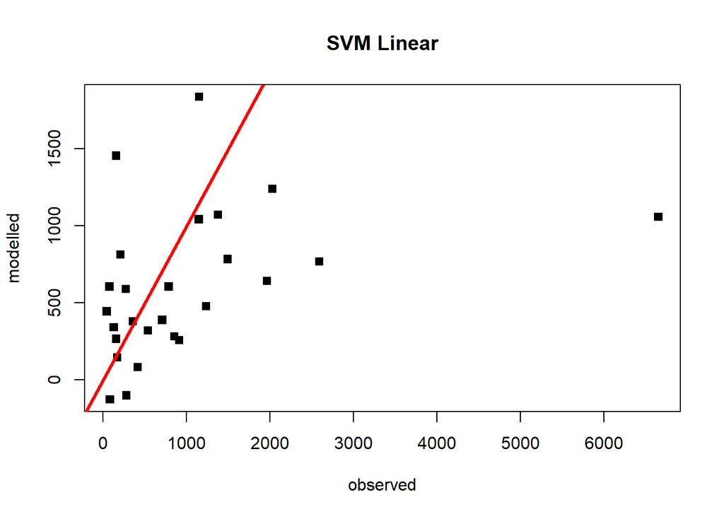

```r
#### Model 6 : SVM Linear Model
svmlinear = e1071::svm(formula = passengers_avg~., data = FILE3D[train,],
                   type = 'eps-regression',
                   kernel = 'linear')

yh  = predict(svmlinear, newdata=FILE3D[-train,])
y   = FILE3D$passengers_avg[-train]
derr(y,yh,"SVM Linear: "); aplot(y,yh,"SVM Linear")
```

```
## Linear Model: rmse=1,120.8, mape=360.4%
```

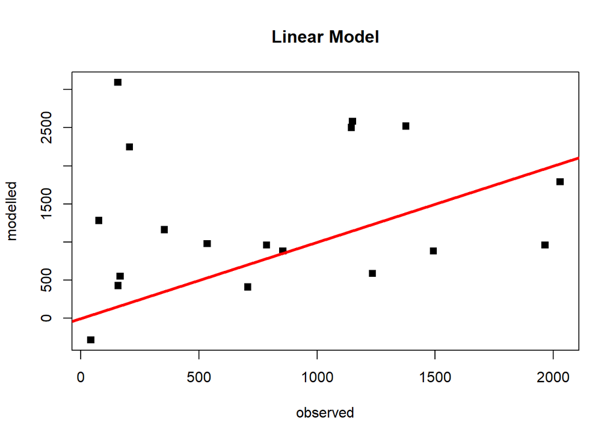

```r
#### Dividing the data in to Test (nr1) and Train (nt1) at 80%

nr1 = length(FILE3D$passengers_avg); nt1=floor(.8*nr1);
set.seed(123); train1 = sample(1:nr1, nt1);


#### Model 1 : Linear Model -

m1<- lm ( passengers_avg~., data = FILE3D[train1,])
yh  = predict(m1, newdata=FILE3D[-train1,])
y   = FILE3D$passengers_avg[-train1]
derr(y,yh,"Linear Model: "); aplot(y,yh,"Linear Model")
```

```r
summary(m1)
```

```
##
## Call:
## lm(formula = passengers_avg ~ ., data = FILE3D[train1, ])
##
## Residuals:
##     Min      1Q  Median      3Q     Max
## -1903.1  -746.8  -189.0   359.7  8200.7
##
## Coefficients:
##                   Estimate Std. Error t value Pr(>|t|)
## (Intercept)        4103.32    3891.32   1.054   0.2958
## hospitals          -200.12     166.07  -1.205   0.2328
## train_stations       84.16     136.85   0.615   0.5408
## logheadway_avg     -455.30     179.18  -2.541   0.0136 *
## log_Deviation_avg -1080.99     528.53  -2.045   0.0451 *
## log_household       805.26     483.09   1.667   0.1007
## Log_length         -165.07     386.99  -0.427   0.6712
## ---
## Signif. codes:  0 '***' 0.001 '**' 0.01 '*' 0.05 '.' 0.1 ' ' 1
##
## Residual standard error: 1475 on 61 degrees of freedom
## Multiple R-squared:  0.2043, Adjusted R-squared:  0.126
## F-statistic:  2.61 on 6 and 61 DF,  p-value: 0.02562
```

```
## Linear Regression: rmse=1,069.1, mape=349.2%
```

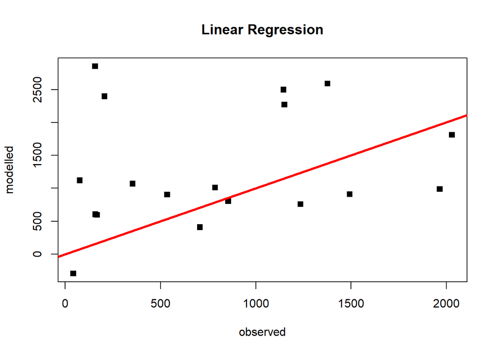

```r
#### Model 2 : Linear Regression


p_load(MASS)
ya = FILE3D$passengers_avg[train1]
pX = FILE3D %>% dplyr::select(-c(passengers_avg))
X = as.matrix( pX[train1,])
b = ginv(t(X) %*% X) %*% t(X) %*% ya

y = FILE3D$passengers_avg[-train1]
Xt = as.matrix( pX[-train1,])
yh = Xt %*% b
derr(y,yh,"Linear Regression: "); aplot(y,yh,"Linear Regression")
```

```
## Random Forest : rmse=1,264.4, mape=322.6%
```

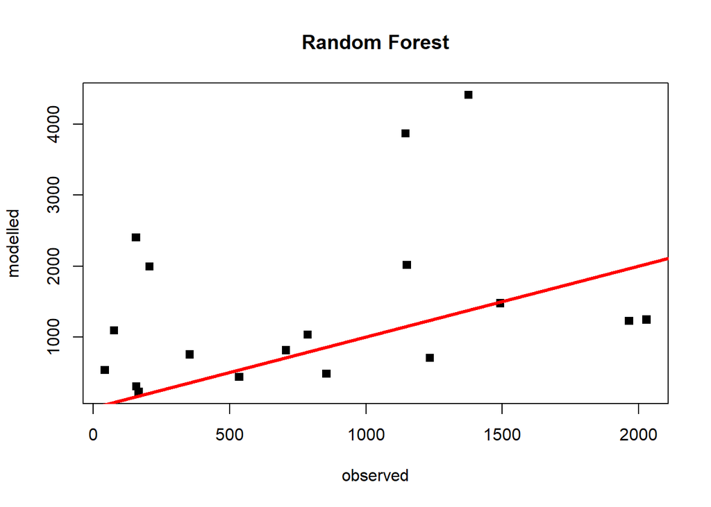

```r
#### Model 3 : Random Forest Model

p_load(randomForest)
set.seed(123);
rf = randomForest(formula = passengers_avg~., data = FILE3D, subset=train1, importance = TRUE)
yh2  = predict(rf, newdata=FILE3D[-train1,])
y2   = FILE3D$passengers_avg[-train1]
derr(y2,yh2,"Random Forest : "); aplot(y2,yh2,"Random Forest")
```

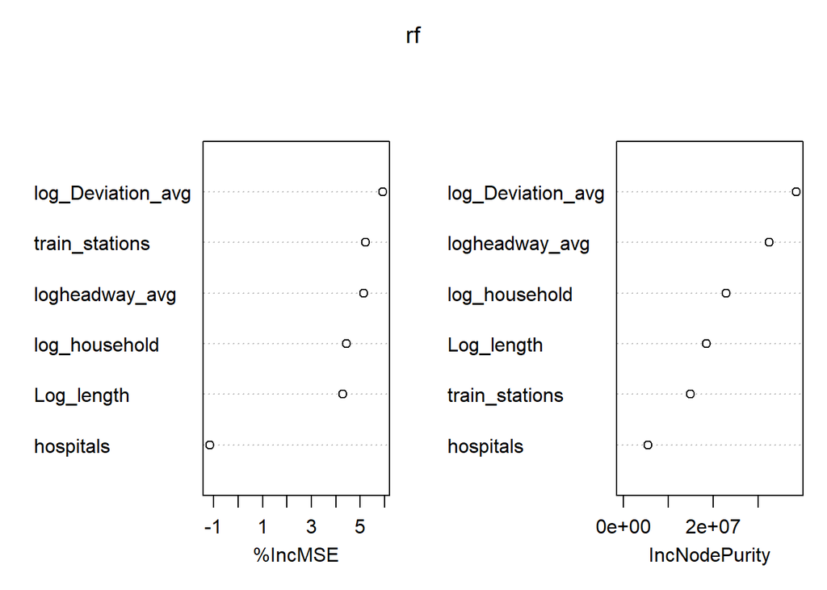

```r
I = importance(rf);I = I[order(-I[,1]),]
varImpPlot(rf)
```

```
## Decision Tree : rmse=1,040.3, mape=330.0%
```

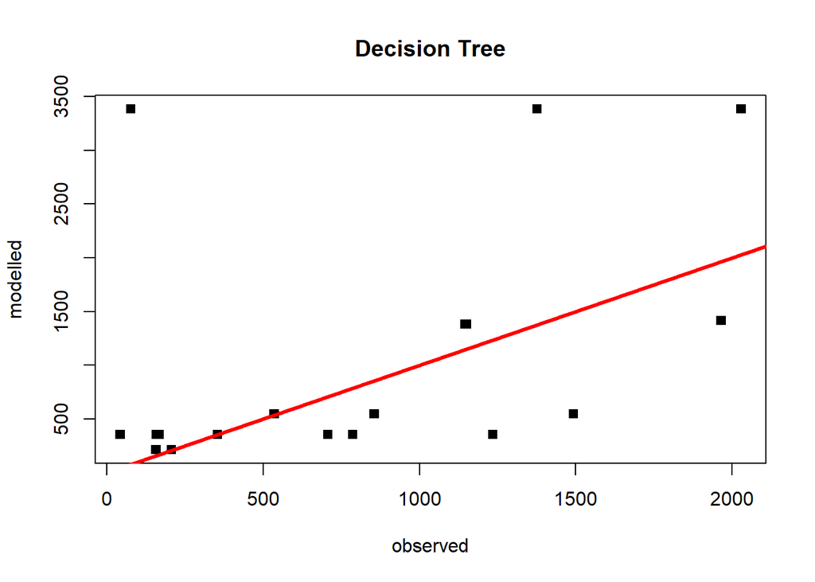

```r
#### Model 4 : Decision Tree
p_load(tree)
dt = tree(passengers_avg~., data = FILE3D, subset=train1)
yh  = predict(dt, newdata=FILE3D[-train1,])
y   = FILE3D$passengers_avg[-train1]
derr(y,yh,"Decision Tree : "); aplot(y,yh,"Decision Tree")
```